# A Study Guide for Quiz 2

Author

Jed Rembold

Published

April 3, 2025

The below materials are meant to provide you a sort of checklist of what you should ensure you are aware of going into the second quiz, as well as providing some example type questions. I’ve tried to specify by the word “Computing” in the outline what topics you should have the equations memorize for, and specify “Qualitatively” when you don’t need to know the specific equation, but just the general trends.

# 1 Outline of Content

**Unit 3: Exoplanets**

- Methods of finding exoplants
  - What is the astrometric method?
    - What orientation of planetary orbits can it detect?
    - What are some drawbacks?
    - What information about a planet could you get from this method?
  - What is the doppler method?
    - What orientation of planetary orbits can it detect?
    - What information about a planet could you get from this method?
    - You do **not** need to know the expression compute the planet’s mass
  - What is the transit method?
    - What orientation of planetary orbits can it detect?
    - What information about a planet could you get from this method?
    - **Computing:** the radius of the planet given transit data and star radius
- In any method, you should be able to determine the planet’s period given simple observational data.

**Unit 4: Galaxies**

- The Milky Way
  - How do/did we determine the shape of the Milky Way?
  - What are the structural components of the Milky Way?
  - How are stars in the halo of the Milky Way different from in the disk?
- What new methods do we have of determining distances?
- Why are Cepheid variables special and useful?
  - **Computing:** How can we use Cepheids to determine distances?
- Different galaxies:
  - What are the different types of galaxies?
  - How are they different from one another?
  - What types of stars appear in each?
  - Which are actively forming new stars?
- Given an image of a galaxy, be able to place it (approximately) on Hubble’s Fork

**Equations to Know**

There aren’t many equations you need to know to be able to solve the computing objectives for these sections:

$$\text{Fraction of light lost} = \frac{\pi R_p^2}{\pi R_s^2}$$

$$L = 4\pi d^2 B_{app}$$

# 2 Example Problems

**Question 1**

Which of the following could be determined about an exoplanet discovered using the *astrometric* method? Check all that apply.

- Its volume
- Its density
- Its mass
- Its period
- Its orbital radius
- Its chemical composition

**Answer**

**Question 2**

You’ve received the below doppler data of a nearby star. What would you determine the period of the surrounding exoplanet to be?

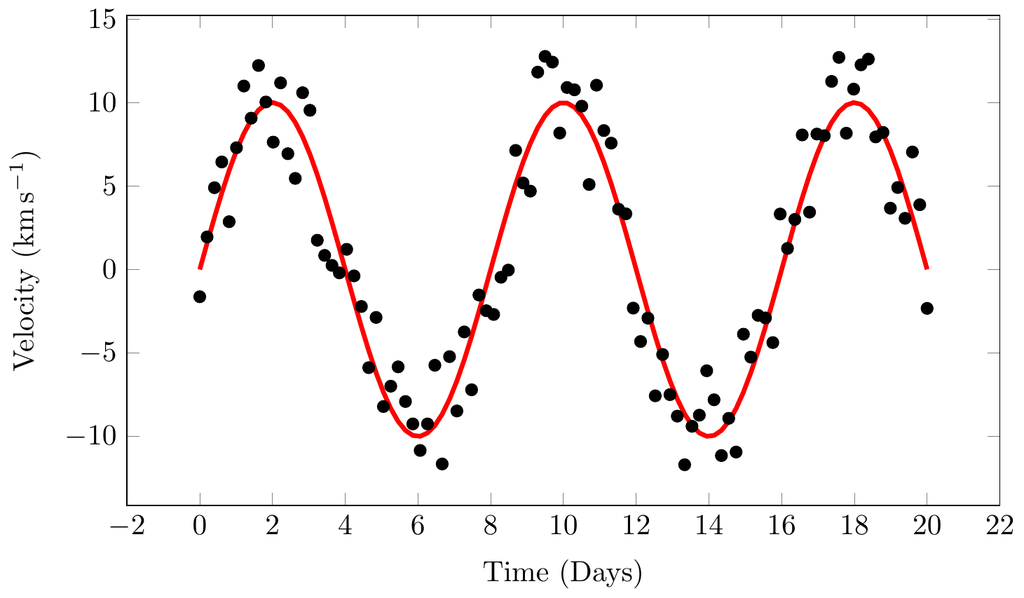

**Answer**

If there is only the single planet around the star (as it looks from the simple sinusoidal behavior of the star), then the planet and star are moving in lockstep around their mutual center of mass. As such, the period of the planet will be the same as the period of the star. Looking off the graph, the period of the star seems to be about 8 days (looking at the troughs centered around 14 days and 6 days). Thus the period of the planet is also 8 days.

**Question 3**

You also received the below transit data for a different exoplanet orbiting a different star. If the star’s radius is 800,000 km, what is the radius of the planet?

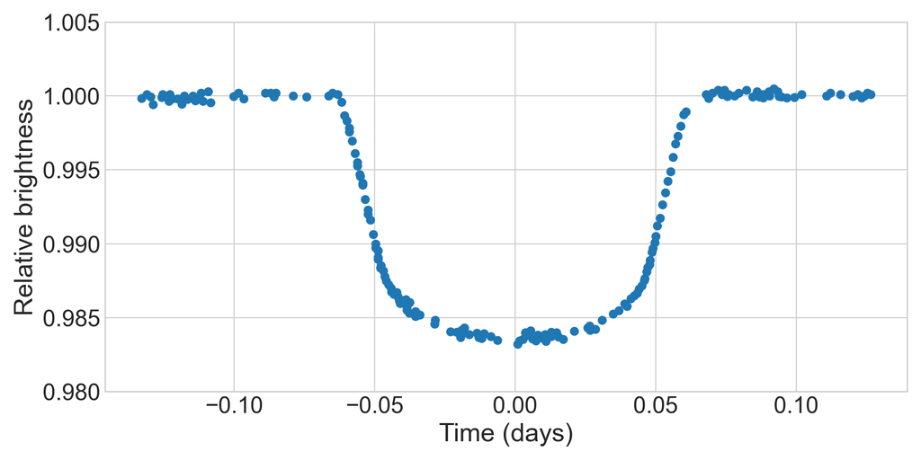

**Answer**

It looks as though the dip in the brightness of the transit goes to about 0.984. Thus we have
$$\begin{aligned}
1 - 0.984 &= \frac{R_p^2}{R_s^2} \\
(0.016)(800000)^2 &= R_p^2 \\
\sqrt{10240000000} &= R_p \\
101193 &= R_p
\end{aligned}$$

**Question 4**

What kinds of objects lie in the halo of our galaxy?

- Open clusters
- O and B type stars
- Globular clusters
- Gas and dust
- Old K and M stars

**Answer**

**Question 5**

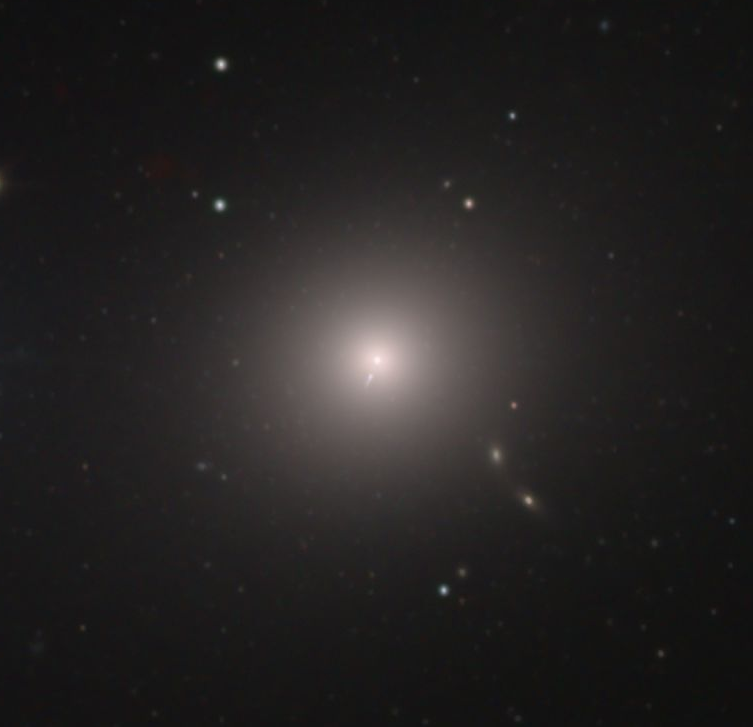

**Answer**

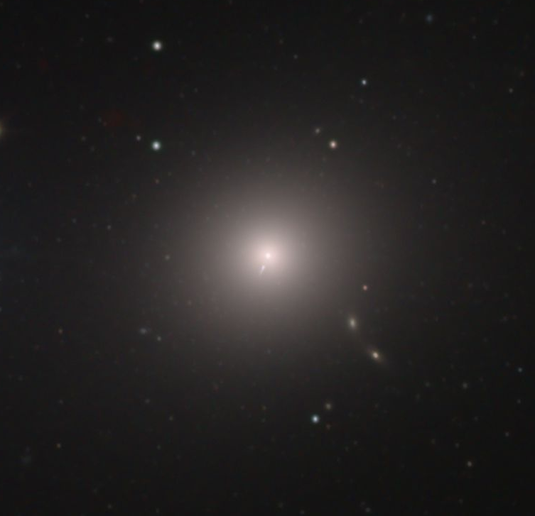

This is definitely an elliptical galaxy and it looks very spherical, hence placing on the far end.

**Question 6**

Compared to our Sun, most stars in the halo are:

1. young, red, dim, and have fewer heavy elements
2. young, blue, bright, and have many more heavy elements
3. old, red, dim and have fewer heavy elements
4. old, red, dim and have many more heavy elements
5. old, red, bright and have fewer heavy elements

**Answer**

Compared to our Sun, most stars in the halo are:

1. young, red, dim, and have fewer heavy elements
2. young, blue, bright, and have many more heavy elements
3. **old, red, dim and have fewer heavy elements**
4. old, red, dim and have many more heavy elements
5. old, red, bright and have fewer heavy elements

**Question 7**

Explain why the spiral arms of galaxies tend to have a blue color.

**Answer**

Spiral arms are the result of spiral density waves, which are regions where the density of gas and stars is increased. This increase in density also makes it easier for new stars to form, some of which could be the shortlived, bright, blue type stars that otherwise die out fairly quickly. So they have the blue-ish color because they are active star-forming regions.

**Question 8**

Why do elliptical galaxies appear yellow or red?

1. They have very little dust or cold gas, and thus have little ongoing star formation
2. They contain only massive stars that have progressed to the red-giant stage
3. They contain no hot, young blue stars
4. a and b
5. a and c

**Answer**

Why do elliptical galaxies appear yellow or red?

1. They have very little dust or cold gas, and thus have little ongoing star formation
2. They contain only massive stars that have progressed to the red-giant stage
3. They contain no hot, young blue stars
4. a and b
5. **a and c**

**Question 9**

Why are Cepheid variables important?

1. Cepheid variables are stars than vary in brightness because they harbor a black hole. Therefore, they provide evidence of the existence of black holes.
2. Cepheid variables are pulsating stars whose pulsation periods are directly related to their true luminosities. Therefore, they can be used as distance indicators.
3. Cepheid variables are a type of irregular galaxy, much more common in the early universe. Thus, they help up understand how galaxies are formed.
4. Cepheid variables are supermassive stars that are on the verge of becoming supernova. Thus, they allow us to choose observational candidates to watch if we hope to observe a supernova.

**Answer**

Why are Cepheid variables important?

1. Cepheid variables are stars than vary in brightness because they harbor a black hole. Therefore, they provide evidence of the existence of black holes.
2. **Cepheid variables are pulsating stars whose pulsation periods are directly related to their true luminosities. Therefore, they can be used as distance indicators.**
3. Cepheid variables are a type of irregular galaxy, much more common in the early universe. Thus, they help up understand how galaxies are formed.
4. Cepheid variables are supermassive stars that are on the verge of becoming supernova. Thus, they allow us to choose observational candidates to watch if we hope to observe a supernova.

**Question 10**

Two Cepheid variables, A and B, are observed, one with a period of 2 days and one with a period of 4 days, respectively. Both are observed to have about the same average apparent magnitude. Use the below table to help determine how many times further away Cepheid B is than Cepheid A.

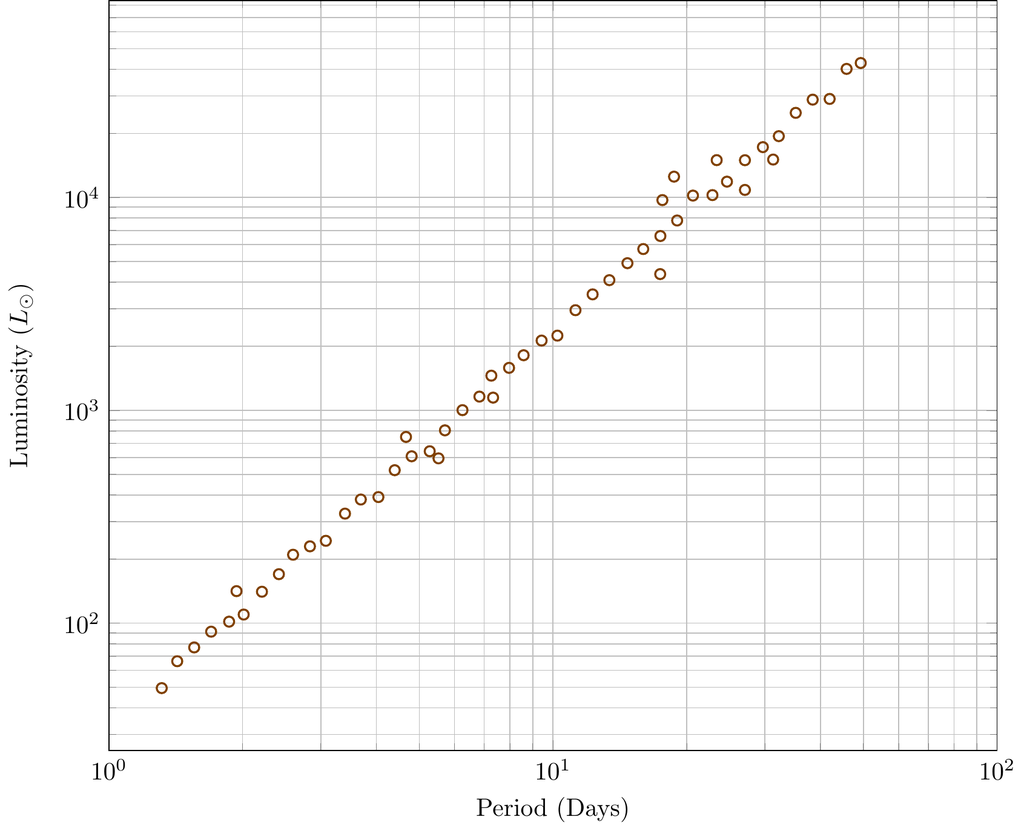

**Answer**

Reading off the log-log plot requires understanding that the first labeled line for each division corresponds to $1\times10^x$, where $x$ is whatever that division is labeled as. Thus the second grid line past that is $2\times10^x$, then $3\times10^x$, and so on. In our case, taking our two stars, we can read their corresponding luminosities off the table.

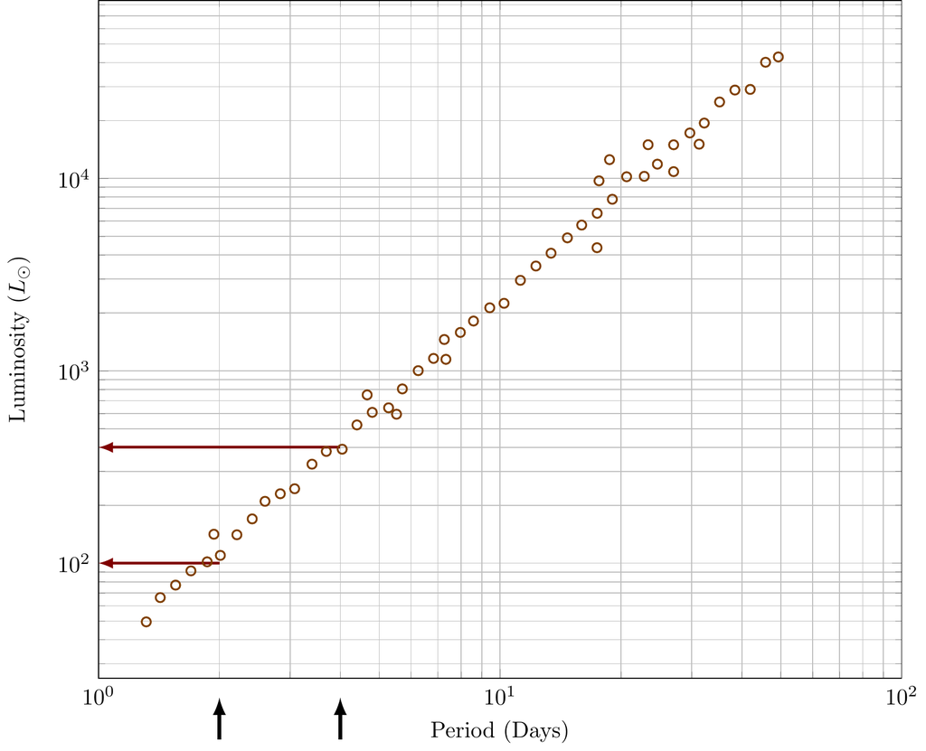

$$\begin{aligned}
L_A &= 100 L_\odot \\
L_B &= 400 L_\odot
\end{aligned}$$
We also know that luminosity scales with distance as
$$L = 4\pi d^2 B_{app}$$
where $B$ is the apparent brightness. In our case, both stars have the same apparent magnitude, so their apparent brightness would be the same. Solving for $B_{app}$ for both stars are setting them equal:
$$\begin{aligned}
\frac{L_A}{4\pi d_A^2} &= \frac{L_B}{4\pi d_B^2} \\
L_A d_B^2 &= L_B d_A^2 \\
100L_\odot d_B^2 &= 400L_\odot d_A^2 \\
d_B^2 &= 4 d_A^2 \\
d_B &= 2 d_A
\end{aligned}$$